# Assignment8

```r
library(tidyverse)
library(broom)
```

# a) Read in and display (some of) the data.

```r
url <- "http://ritsokiguess.site/datafiles/construction.csv"
construction <- read_csv(url)
head(construction)
```

| completion_time | size | bad_weather | strike | subcontractors |
| --- | --- | --- | --- | --- |
| 29 | 60 | 7 | 0 | 7 |
| 15 | 80 | 10 | 0 | 8 |
| 60 | 100 | 8 | 1 | 10 |
| 10 | 50 | 14 | 0 | 5 |
| 70 | 200 | 12 | 1 | 11 |
| 15 | 50 | 4 | 0 | 3 |

# b) Fit a suitable regression, predicting the response variable from everything else, and display the results.

```r
new_construction = construction %>% mutate(strike_c = as.character(strike))
new_construction
```

| completion_time | size | bad_weather | strike | subcontractors | strike_c |
| --- | --- | --- | --- | --- | --- |
| 29 | 60 | 7 | 0 | 7 | 0 |
| 15 | 80 | 10 | 0 | 8 | 0 |
| 60 | 100 | 8 | 1 | 10 | 1 |
| 10 | 50 | 14 | 0 | 5 | 0 |
| 70 | 200 | 12 | 1 | 11 | 1 |
| 15 | 50 | 4 | 0 | 3 | 0 |
| 75 | 500 | 15 | 1 | 12 | 1 |
| 30 | 75 | 5 | 0 | 6 | 0 |
| 45 | 750 | 10 | 0 | 10 | 0 |
| 90 | 1200 | 20 | 1 | 12 | 1 |

[output cut: 5 more lines]

```r
regression_b <- lm(data = construction, completion_time ~ size + bad_weather + strike_c + subcontractors)
tidy(regression_b)
```

[output not shown]

Therefore, construction_time = -1.72089 - 0.00787size + 0.67016bad_weather + 27.71373strike + 3.53468subcontractors

# c)Build a good model for predicting completion time, using backward elimination with a=0.10. Describe your process.

```r
regression_c <-step(regression_b, direction = "backward", test = "F")
```

```
Start:  AIC=78.05
completion_time ~ size + bad_weather + strike_c + subcontractors

                 Df Sum of Sq    RSS    AIC F value  Pr(>F)
- bad_weather     1     63.04 1464.2 76.715  0.4499 0.51756
<none>                        1401.1 78.055
- size            1    224.07 1625.2 78.280  1.5993 0.23468
- subcontractors  1    468.10 1869.2 80.378  3.3409 0.09752 .
- strike_c        1    833.35 2234.5 83.056  5.9478 0.03492 *
---
Signif. codes:  0 ‘***’ 0.001 ‘**’ 0.01 ‘*’ 0.05 ‘.’ 0.1 ‘ ’ 1

Step:  AIC=76.71
completion_time ~ size + strike_c + subcontractors

                 Df Sum of Sq    RSS    AIC F value  Pr(>F)
- size            1    191.54 1655.7 76.559  1.4391 0.25549
<none>                        1464.2 76.715
- subcontractors  1    661.27 2125.4 80.305  4.9680 0.04762 *
- strike_c        1    954.50 2418.7 82.244  7.1710 0.02149 *
---
Signif. codes:  0 ‘***’ 0.001 ‘**’ 0.01 ‘*’ 0.05 ‘.’ 0.1 ‘ ’ 1

Step:  AIC=76.56
completion_time ~ strike_c + subcontractors

                 Df Sum of Sq    RSS    AIC F value  Pr(>F)
<none>                        1655.7 76.559
- subcontractors  1    475.21 2130.9 78.344  3.4442 0.08819 .
- strike_c        1    956.17 2611.9 81.397  6.9301 0.02187 *
---
Signif. codes:  0 ‘***’ 0.001 ‘**’ 0.01 ‘*’ 0.05 ‘.’ 0.1 ‘ ’ 1
```

```r
tidy(regression_c)
```

| term | estimate | std.error | statistic | p.value |
| --- | --- | --- | --- | --- |
| (Intercept) | 5.167669 | 10.351985 | 0.4991959 | 0.62666711 |
| strike_c1 | 29.163158 | 11.078115 | 2.6325018 | 0.02187443 |
| subcontractors | 2.988722 | 1.610436 | 1.8558463 | 0.08819011 |

# d) For your best model, obtain a full set of residual plots.

Fitted vs Residual:

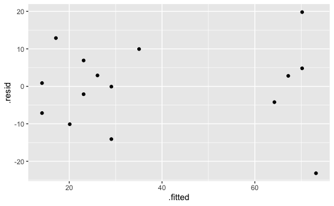

```r
regression_c %>% ggplot(aes(x = .fitted, y= .resid)) + geom_point()
```

normal quantile plot of residuals:

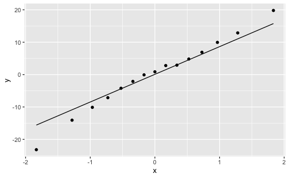

```r
regression_c %>% ggplot(aes(sample = .resid)) + geom_qq() + geom_qq_line()
```

residuals vs each of the explanatory variables:

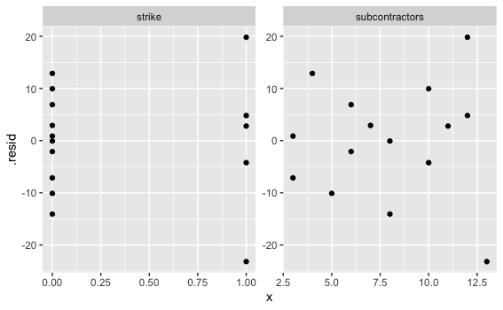

```r
plot <- augment(regression_c, construction) %>%
  pivot_longer(c(strike,subcontractors),
               names_to = "xnames", values_to = "x")
plot %>%
  ggplot(aes(x = x, y = .resid))+
  geom_point()+
  facet_wrap(~xnames,scale = "free")
```

# e) Comment briefly on your plots, and how they support the regression being basically satisfactory. You may assume that all the data values were correctly recorded.

1. The values in the plot of Fitted vs Residual is relatively random, and they’re fairly evenly distributed. This means that the error distribution conforms to guaasian-Markov Condition so is supports the regression being basically satisfactory.
2. The normal quantile plot of residuals is shown by qqplot, it is relatively normal. What this graph does to supports the regression being basically satisfactory is check that the error is normally distributed.
3. The values in the plot of Residual vs each explanatory variable is relatively random. Regression being basically satisfactory is supported by expecting resists to be randomly distributed and to show no regularities.

Therefore, our fit is good.